# R Plots Implemented with Base R and ggplot2

DSA400W Class at Chatham University, Fall 2021

9/21/2021

## Overview

This document will explore the implementation of various types of plots that can be produced with base R graphics and/or the ggplot2 package. For each plot type we begin by showing basic plots and then enhance the plots by combining plot types, adding new variables using faceting, color, shape or size, or customizing colors, axes, axis labels, annotations or styles.

## Load Libraries

```r
library(tidyverse)
library(vioplot)
library(ggmosaic)
library(scales) # provides alpha() function to set alpha for base R plots
```

## Histogram

### Basic Histogram (Base R)

Use the Iris dataset. Show distribution of petal width.

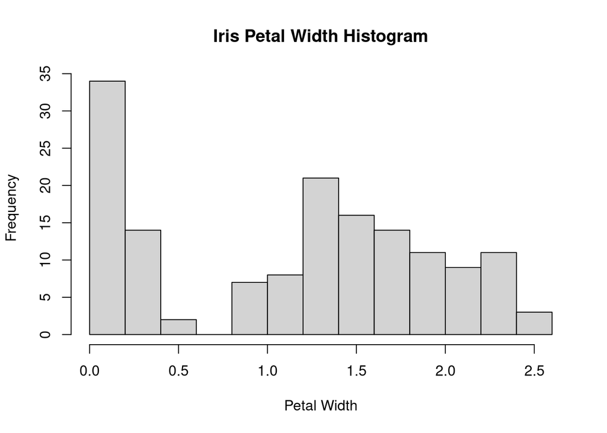

```r
hist(iris$Petal.Width,
     main = "Iris Petal Width Histogram",
     xlab = "Petal Width")
```

### Customized Histogram using Base R

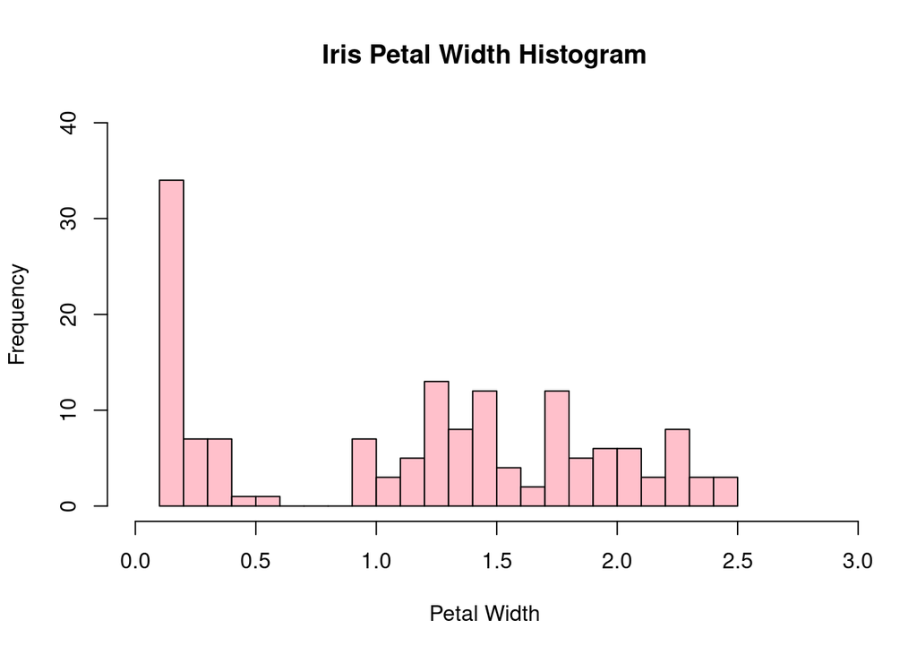

```r
hist(iris$Petal.Width,
     main = "Iris Petal Width Histogram", xlab = "Petal Width", col='pink', breaks=20, xlim=c(0, 2.9), ylim=c(0, 40))
```

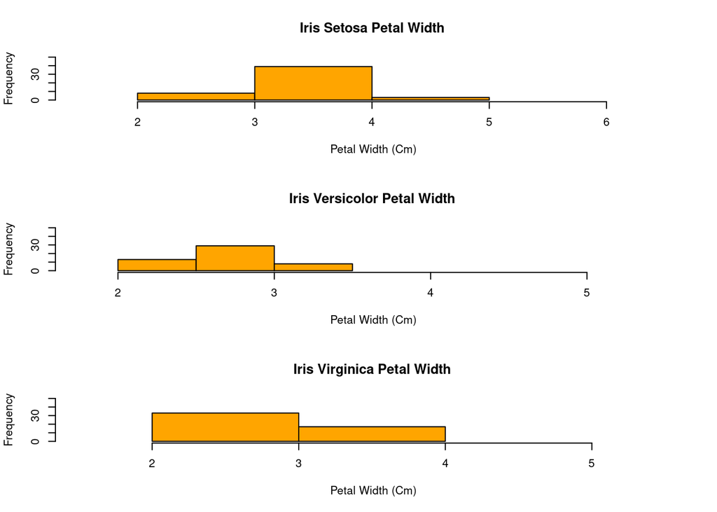

```r
#Subsetting the different species
set <- iris$Sepal.Width[iris$Species == "setosa"]
ver <- iris$Sepal.Width[iris$Species == "versicolor"]
vir <- iris$Sepal.Width[iris$Species == "virginica"]
par(mfrow = c(3, 1))
hist(set, main = "Iris Setosa Petal Width", xlab = " Petal Width (Cm)", ylab="Frequency", col='orange', breaks=2.5, xlim=c(1.5, 6.5), ylim=c(0, 50))
hist(ver, main = "Iris Versicolor Petal Width", xlab = " Petal Width (Cm)", ylab="Frequency", col='orange', breaks=2.5, xlim=c(1.75, 5.5), ylim=c(0, 50))
hist(vir, main = "Iris Virginica Petal Width", xlab = " Petal Width (Cm)", ylab="Frequency", col='orange', breaks=2.5, xlim=c(1.5, 5.5), ylim=c(0, 50))
```

### Basic Histogram using GGPlot2

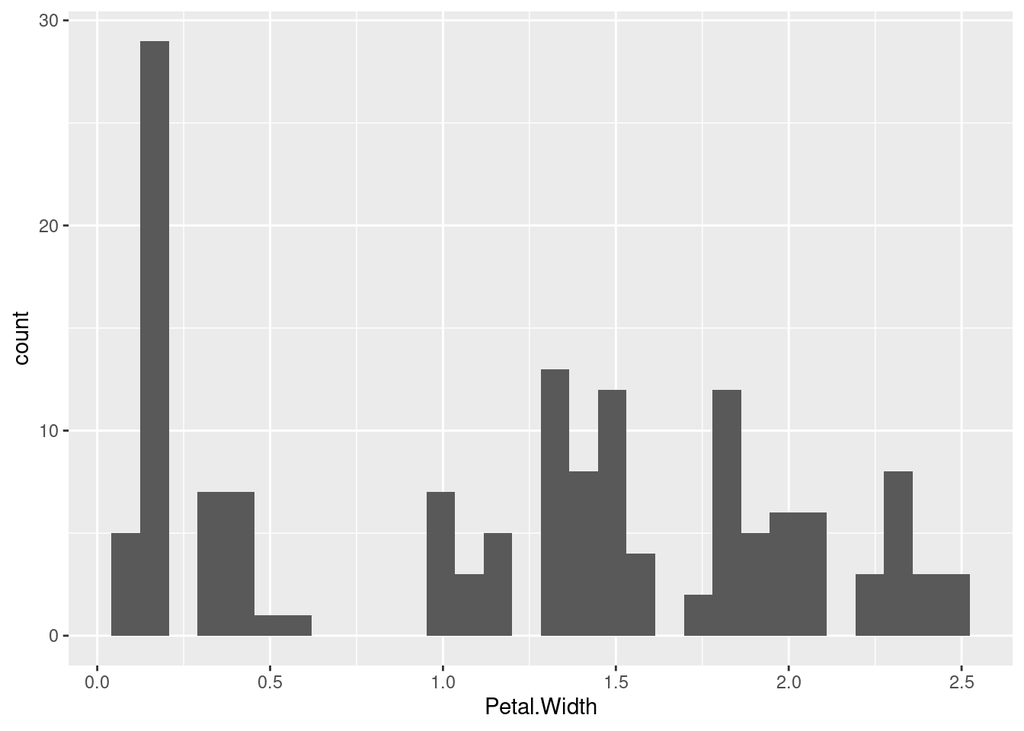

```r
ggplot(iris, aes(x=Petal.Width)) +
  geom_histogram()
```

### Customized Histogram using GGPlot2

Changing the bins, color, outline color, adding title, and adding x and y labels

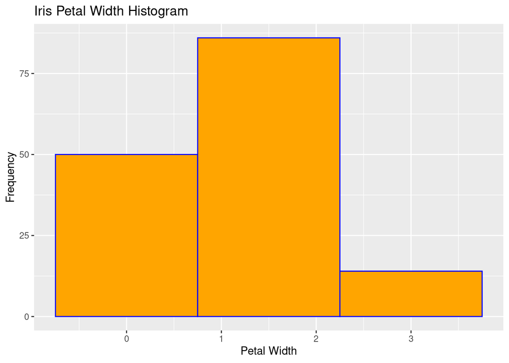

```r
ggplot(iris, aes(x=Petal.Width)) +
  geom_histogram(binwidth=1.5, color="Blue", fill="orange") +
  ggtitle("Iris Petal Width Histogram") +
  xlab("Petal Width") +
  ylab("Frequency")
```

### GGPlot2 Histogram with Species Added in

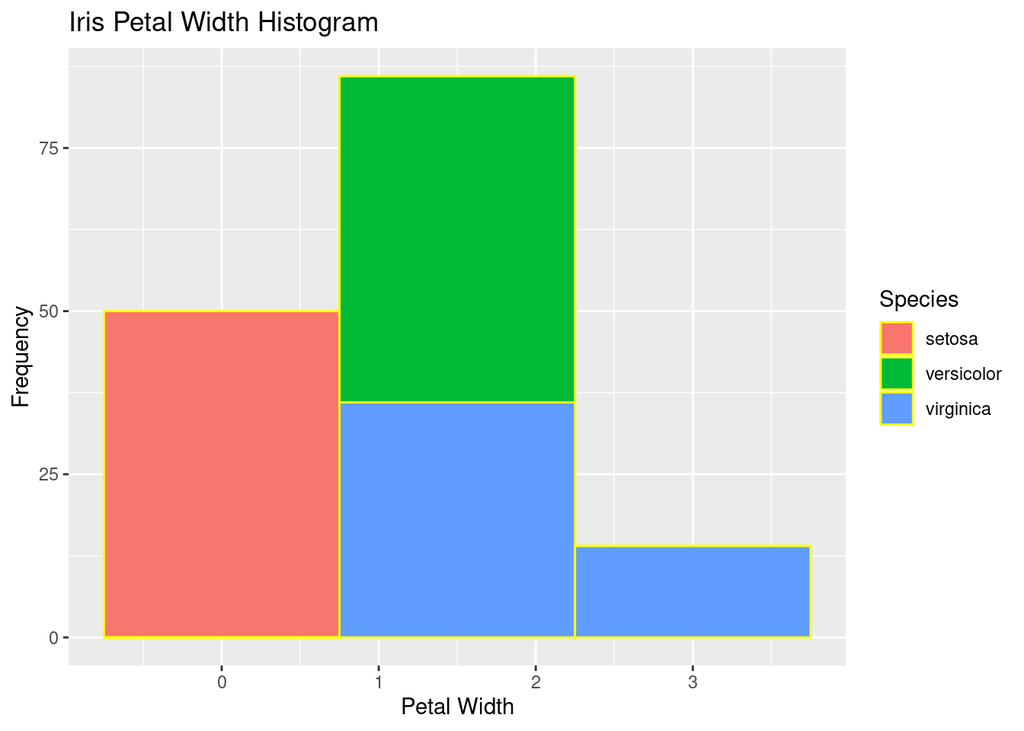

```r
ggplot(iris, aes(x=Petal.Width)) +
  geom_histogram(binwidth=1.5, color="yellow", aes(fill=Species)) +
  ggtitle("Iris Petal Width Histogram") +
  xlab("Petal Width") +
  ylab("Frequency")
```

### Creating Histograms for each Species on Petal Width using GGPlot2

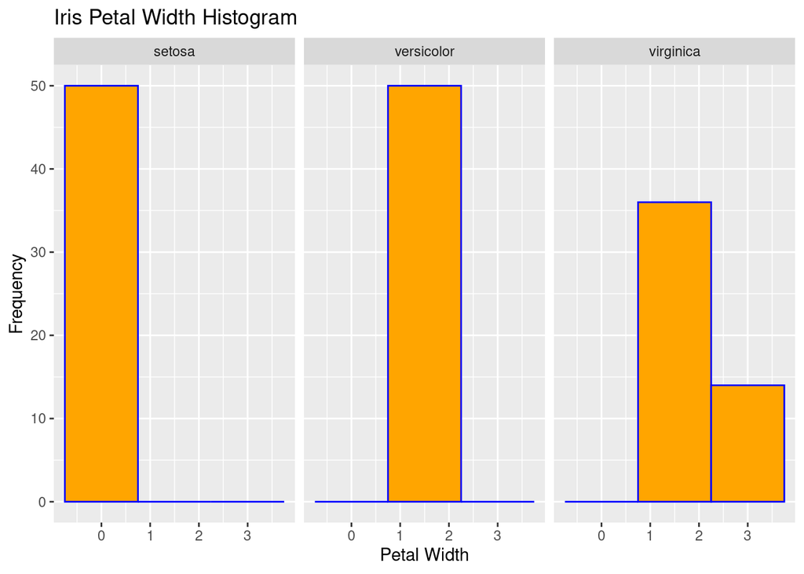

```r
ggplot(iris, aes(x=Petal.Width)) +
  geom_histogram(binwidth=1.5, color="blue", fill="orange") + ggtitle("Iris Petal Width Histogram") + xlab("Petal Width") + ylab("Frequency") +
  facet_grid(. ~ Species)
```

## Density Curve

### Basic Density Curve Using Base R

```r
# get a dataset from R
# Orange dataset has information about the growth of orange trees
orange <- Orange
```

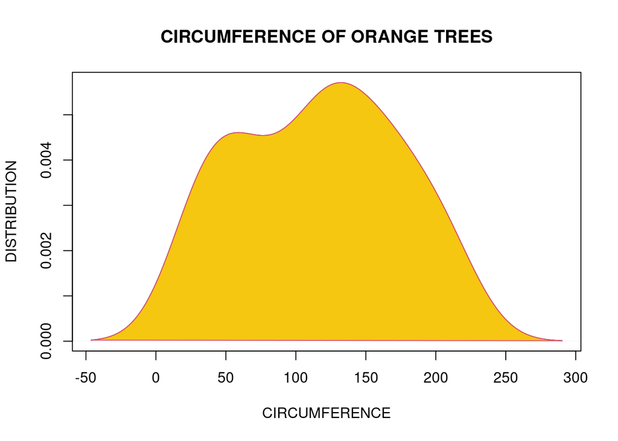

```r
# create a density plot
plot(density(orange$circumference),
     main = "CIRCUMFERENCE OF ORANGE TREES",
     xlab = "CIRCUMFERENCE",
     ylab = "DISTRIBUTION")

polygon(density(orange$circumference), col=7, border=2)
```

### Basic Density Curve Using GGPlot2

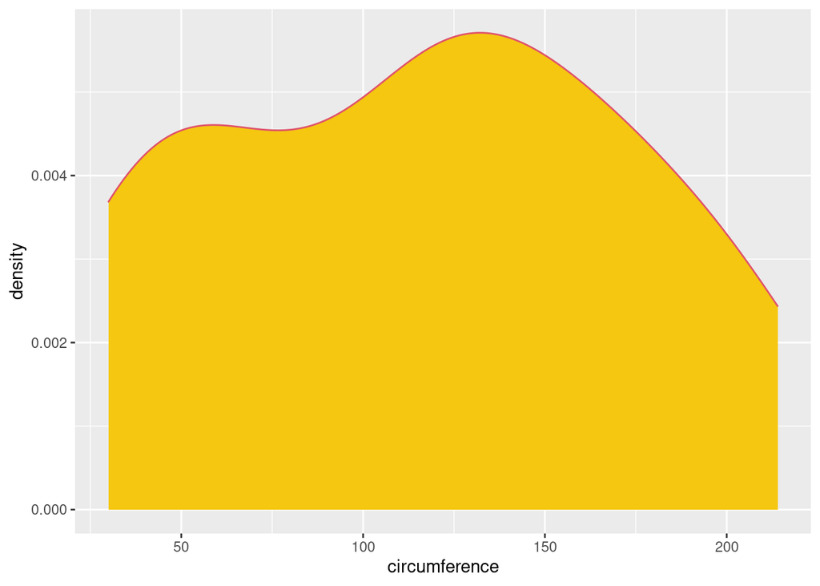

```r
# create the density plot

orange %>%
  ggplot( aes(x = circumference)) +
  geom_density(fill= 7, color= 2)
```

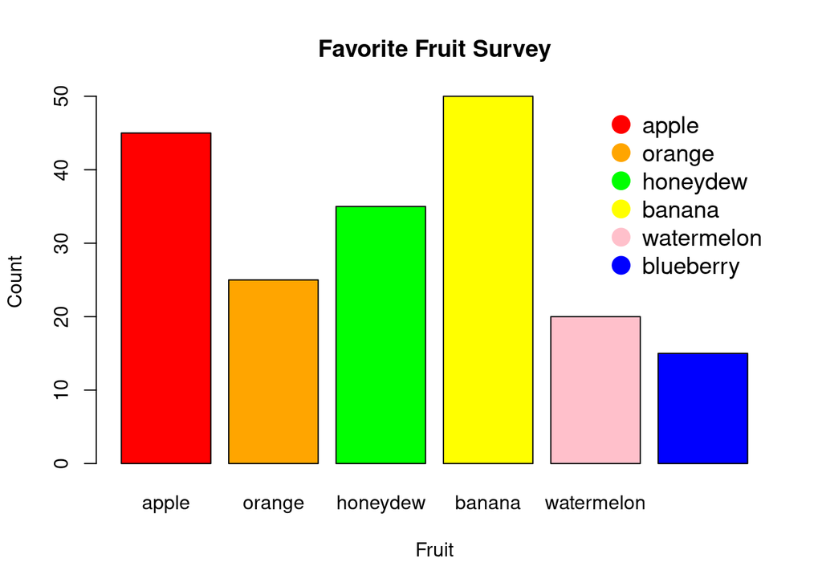

```r
### Create a data set to work with
survey <- c(apple=45, orange=25, honeydew=35, banana=50, watermelon=20, blueberry=15)

### Create a barchart with titles and color
barplot(survey,
        main="Favorite Fruit Survey",
        xlab="Fruit",
        ylab="Count",
        col=c("red", "orange", "green", "yellow", "pink", "blue"))

### Add a legend
legend("topright",
       legend = c("apple", "orange", "honeydew", "banana", "watermelon", "blueberry"),
       col = c("red", "orange", "green", "yellow", "pink", "blue"),
       pch = 19,
       bty = "n",
       pt.cex = 2,
       cex = 1.2)
```

### GGplot2

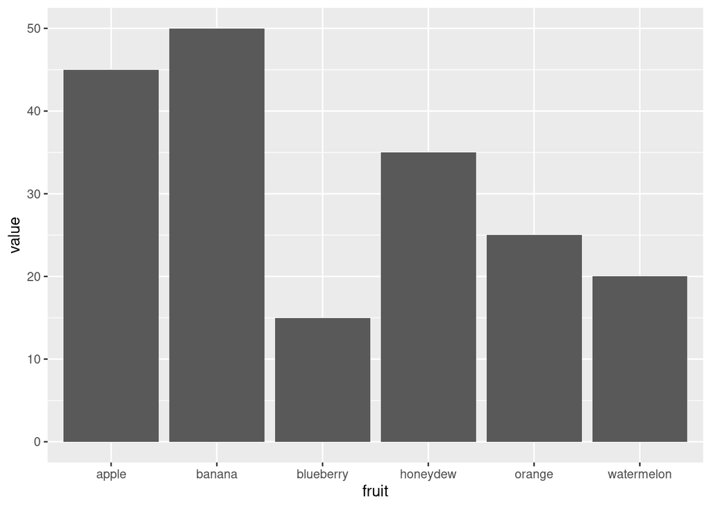

```r
# Use the same data set created in the base r example but make it into a data frame
survey1 <- data.frame(
  fruit=c("apple", "orange", "honeydew", "banana", "watermelon", "blueberry"),
  value=c(45, 25, 35, 50, 20, 15))

# Create the barchart
ggplot(survey1, aes(x=fruit, y=value)) + geom_bar(stat="identity")
```

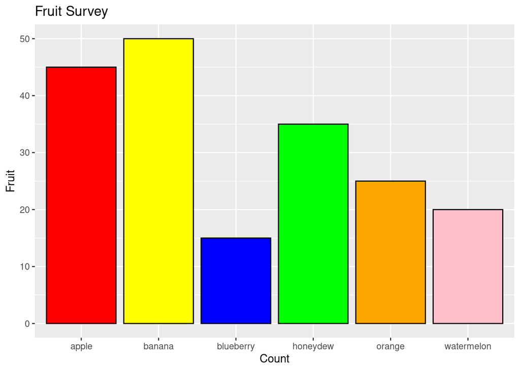

```r
# Add color with black outlines
ggplot(survey1, aes(x=fruit, y=value)) + geom_bar(stat="identity", fill=c("red", "orange", "green", "yellow", "pink", "blue"), color="black") + labs(x="Count", y="Fruit", title="Fruit Survey") + theme(legend.position = "none")
```

### Bar plot with data added above the bars (Base R) First, let’s read in some data on passengers who were aboard the *Titanic*.

```r
titanic <- read.csv("data/titanic.csv")
```

Next, calculate survival percentage and class count for each passenger class, using the `aggregate()` function, and then merge those two results into a data frame.

```r
# calculate survival percentage by class and count by class.
surv_pct <- aggregate(Survived ~ Pclass, data = titanic, FUN = mean)
class_ct <- aggregate(Survived ~ Pclass, data = titanic, FUN = length)

# Merge those two results into a single data frame, and specify
# column names
by_class_data <- merge(surv_pct, class_ct,
                       by = "Pclass")
colnames(by_class_data) <- c("Pclass", "Surv_Pct", "Count")
#str(by_class_data)
```

Create the barplot. Note that we increase the `ylim` parameter a bit to leave room for labels above the bars. We also set `axes = FALSE` so that the default y-axis is not plotted. Note also that we assign the barplot object to a variable. What gets assigned to the variable is the x positions of the midpoints of each of the bars on the plot. We will use those x positions later to position the labels above the bars, since the x position for a text label specifies the center of the label.

In the next step we create a custom y-axis with the `axis()` function. The `at` parameter specifies the placement of the tick marks on the axis (“axis ticks”) and the `labels` parameter specifies the tick labels. Use the `paste()` function to make percentage labels.

Finally, we create the labels showing the count of passengers in each class and place them right above the bars. The x position comes from the barplot object and the y position is just the height of the bars plus a little extra so that the text labels don’t overlap the bars.

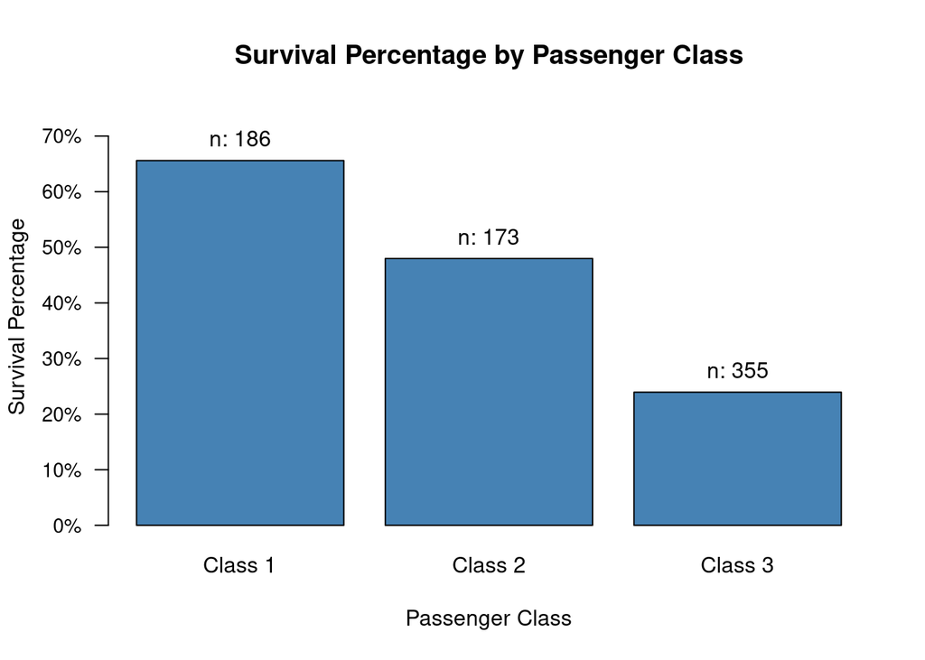

```r
plt <- barplot(by_class_data$Surv_Pct,
               names.arg = paste("Class", by_class_data$Pclass),
               col = 'steelblue',
               main = "Survival Percentage by Passenger Class",
               ylab = "Survival Percentage",
               xlab = "Passenger Class",
               ylim = c(0.0, 0.75),
               axes = FALSE
)

# Add y axis
axis(2, at = seq(0.0, 0.7, by = 0.1),
     labels = paste(seq(0, 70, by = 10), "%", sep=""),
     las = 1,
     cex.axis = 0.9)

# Add the text of the labels
text(x = plt,
     y = by_class_data$Surv_Pct + 0.04,
     labels = paste("n: ", by_class_data$Count, sep=""),
     cex=1)
```

### Bar plot with data added above the bars (ggplot2)

First, let’s read in some data on passengers who were aboard the *Titanic*. For the `ggplot2` example we will use the `tidyverse` approach.

```r
titanic <- read_csv("data/titanic.csv")
```

Next, calculate survival percentage and class count for each passenger class.

```r
survival <- titanic %>%
  group_by(Pclass) %>%
  summarize(Count = n(),
            Surv_Pct = mean(Survived))
```

Make the plot.

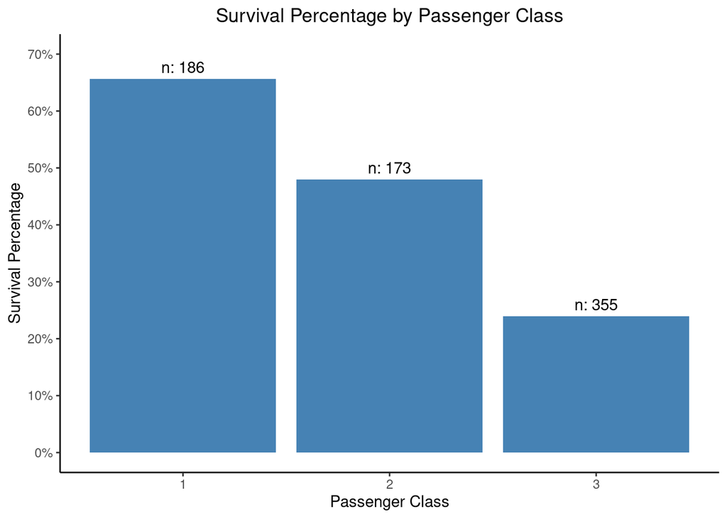

```r
ggplot(survival, aes(x = Pclass, y = Surv_Pct)) +
  geom_col(fill = "steelblue") +
  geom_text(aes(label = paste("n: ", Count, sep="")), vjust = -0.5) +
  xlab("Passenger Class") +
  ylab("Survival Percentage") +
  ggtitle("Survival Percentage by Passenger Class") +
  scale_y_continuous(limits = c(0, 0.70),
                     breaks = seq(0, .7, by = 0.10),
                     labels = paste(seq(0, 70, by = 10), "%", sep=""))  +
  theme_classic() +
  theme(plot.title = element_text(hjust = 0.5)) # Centers title
```

## Stacked Area Plot

Data is total steel produced annually from the 5 largest steel producing countries

```r
steel <- read.csv("data/steel.csv")
```

Make the plot. geom_area() is the function that produces the stacked area plot.

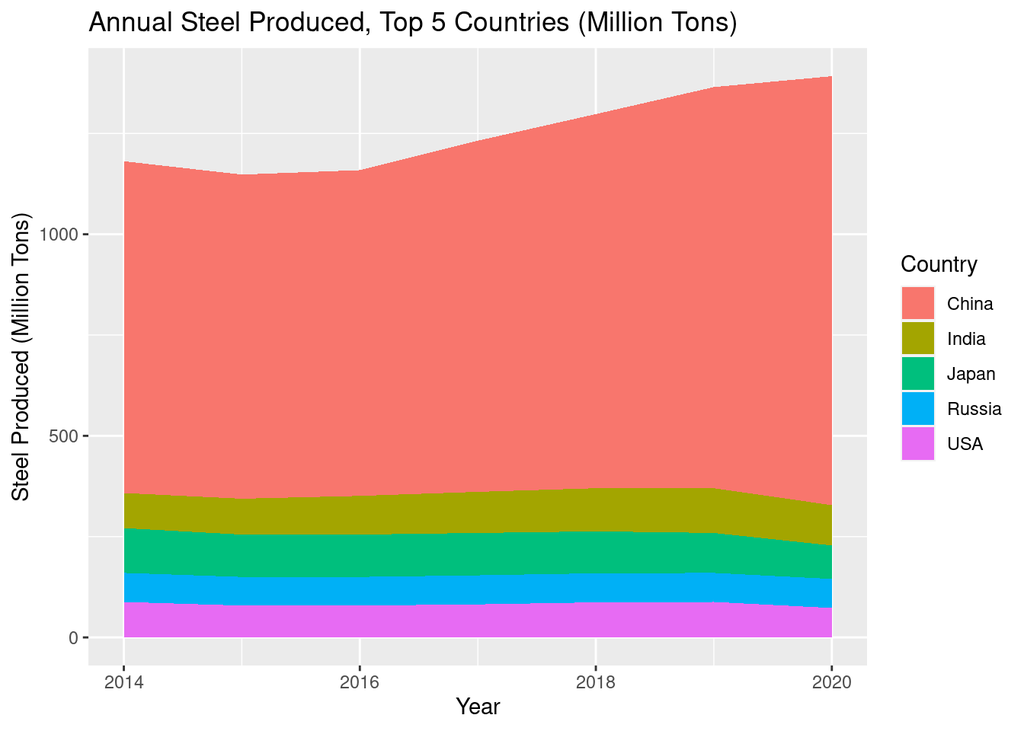

```r
ggplot(steel, aes(x=year, y=Steel, fill=Country)) +
    geom_area() + ggtitle("Annual Steel Produced, Top 5 Countries (Million Tons)") + ylab("Steel Produced (Million Tons)") + xlab("Year")
```

## Boxplot

In the Boxplot section add two basic boxplot examples, one utilizing base R and one utilizing ggplot2. Note that even basic examples should have appopriate titles and axis labels.

Base R:

```r
# Some data to work with:
data(ChickWeight)
```

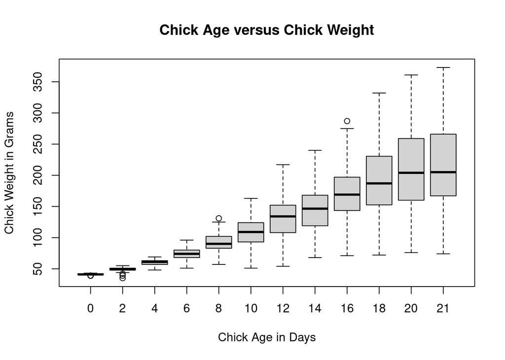

```r
#Boxplot:
boxplot(ChickWeight$weight ~ ChickWeight$Time,
        main = "Chick Age versus Chick Weight",
        xlab = "Chick Age in Days",
        ylab = "Chick Weight in Grams")
```

ggplot2:

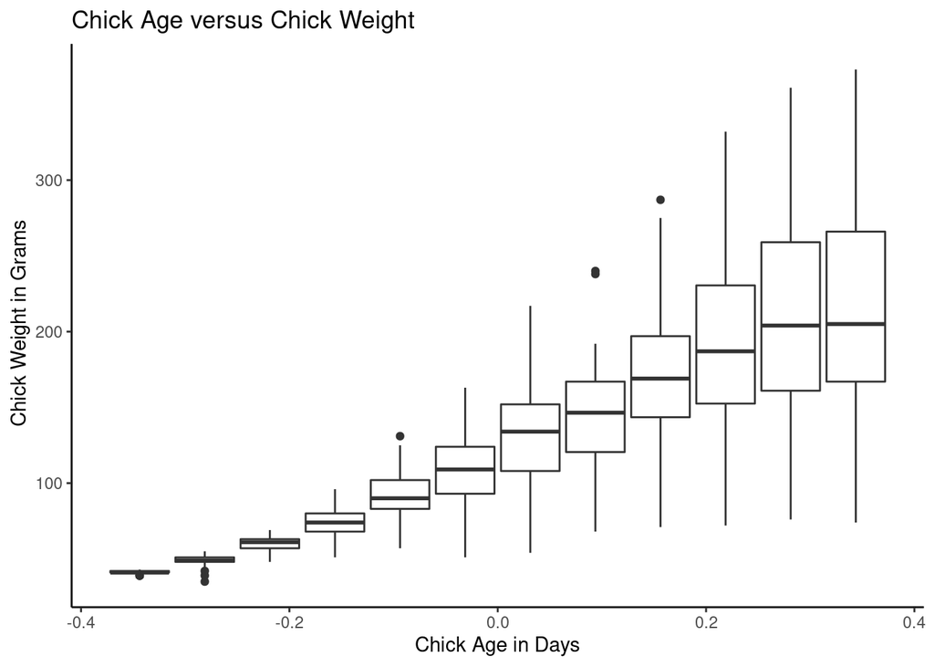

```r
p <- ggplot(ChickWeight, aes(group=Time, y=weight)) +
  geom_boxplot() +
  labs(title="Chick Age versus Chick Weight",x="Chick Age in Days", y = " Chick Weight in Grams")+
  theme_classic()
p
```

## Violin Plot

Let’s pull the NBA Players data

```r
nba_players <- read_csv("data/nba_players.csv")
```

Pulling data from OKC, UTA, and CHI

```r
team <- c(nba_players$TEAM[nba_players$TEAM %in% c("OKC", "UTA", "CHI")])
pts <- c(nba_players$PTS[nba_players$TEAM %in% c("OKC", "UTA", "CHI")])
data <- data.frame(team, pts)
```

### Basic Plot with Base R

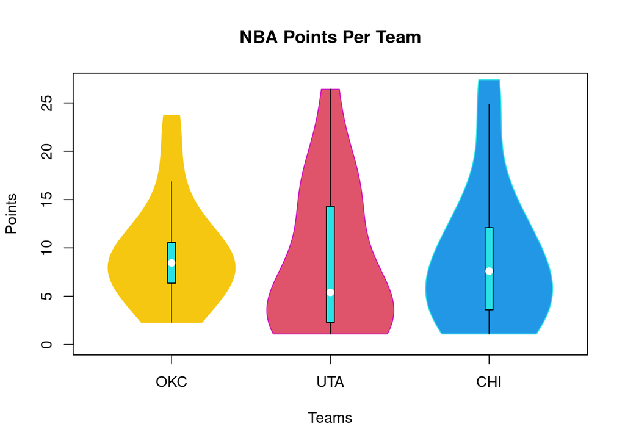

```r
with(data , vioplot(
  pts[team=="OKC"] , pts[team=="UTA"], pts[team=="CHI"],
  col= c(255,234,268) , names=c("OKC","UTA","CHI"),
  xlab = "Teams",
  ylab = "Points",
  main = "NBA Points Per Team",
  ylim = c(0,27),
  border = c(sample(200:900, 3)),
  rectCol = c(893)
))
```

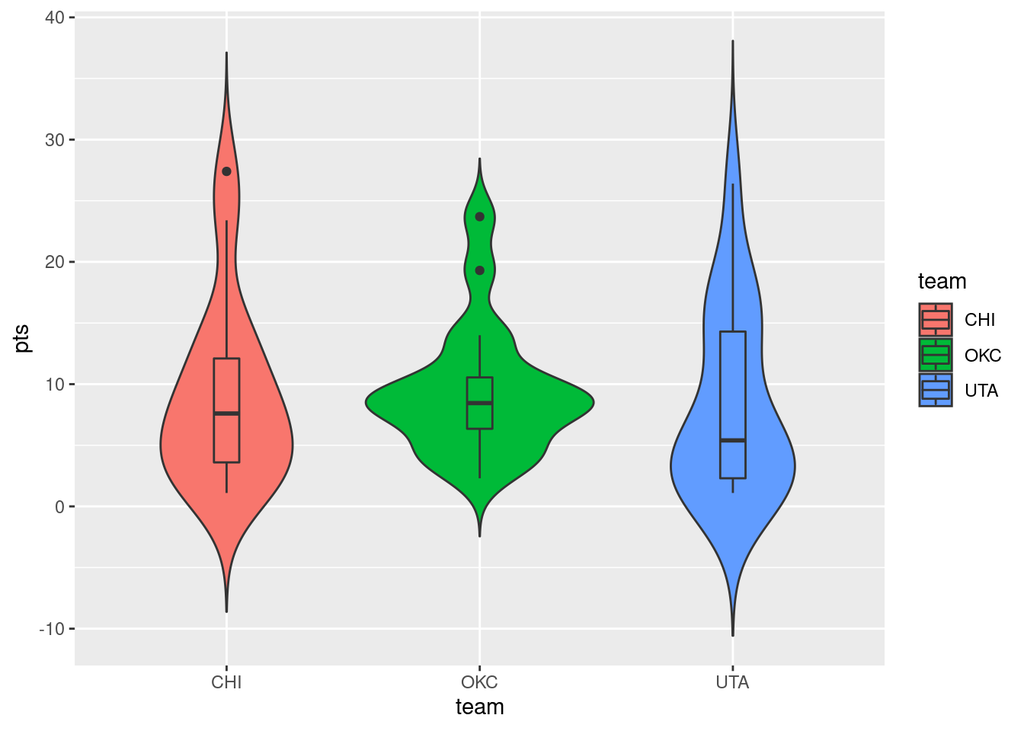

```r
ggplot(data, aes(x= team, y = pts, fill = team)) +
  geom_violin(trim = F, show.legend = T) +
  geom_boxplot(width = 0.1)
```

## Strip Chart

### Strip chart in base R

#### Use the built-in dataset: iris to create a stripchart for the variable Sepal.Width

Here we can use the `alpha()` function from the `scales` package to set an alpha (transparency) level for the color, ranging from 0 (totally transparent) to 1 (totally translucent). `method - 'jitter'` adds random noise in the y-dimension and the `jitter()` function applied to the variable being plotted adds random noise to the actual values of the variable. `amount = 0` causes that random noise to be z/50 where z is the range of the variable.

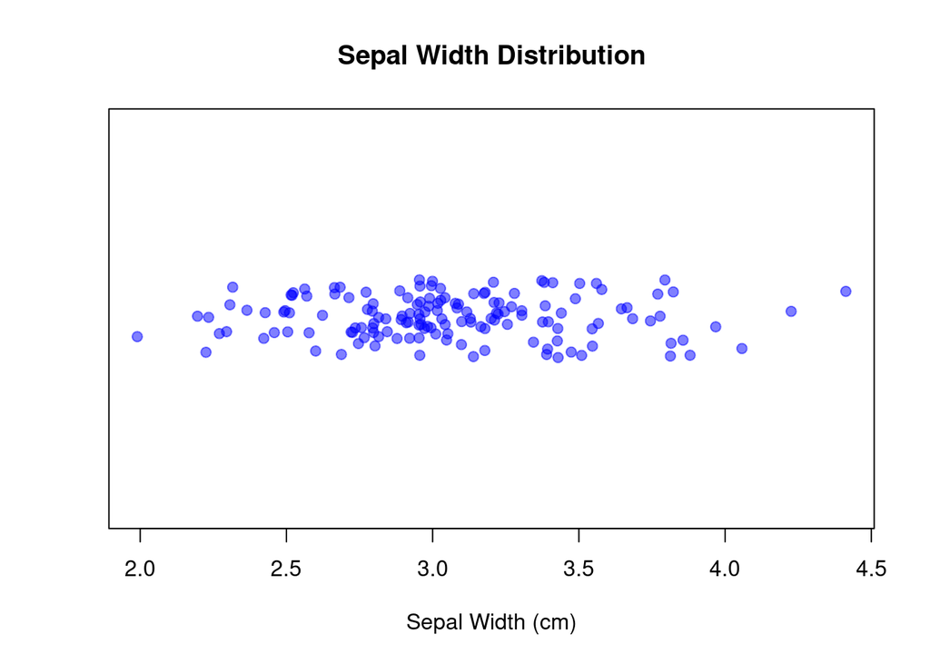

```r
stripchart(jitter(iris$Sepal.Width, amount = 0),
           main = "Sepal Width Distribution",
           xlab = "Sepal Width (cm)",
           col= alpha("blue", 0.5),
           pch = 19,
           method= 'jitter')
```

### Strip chart in ggplot2

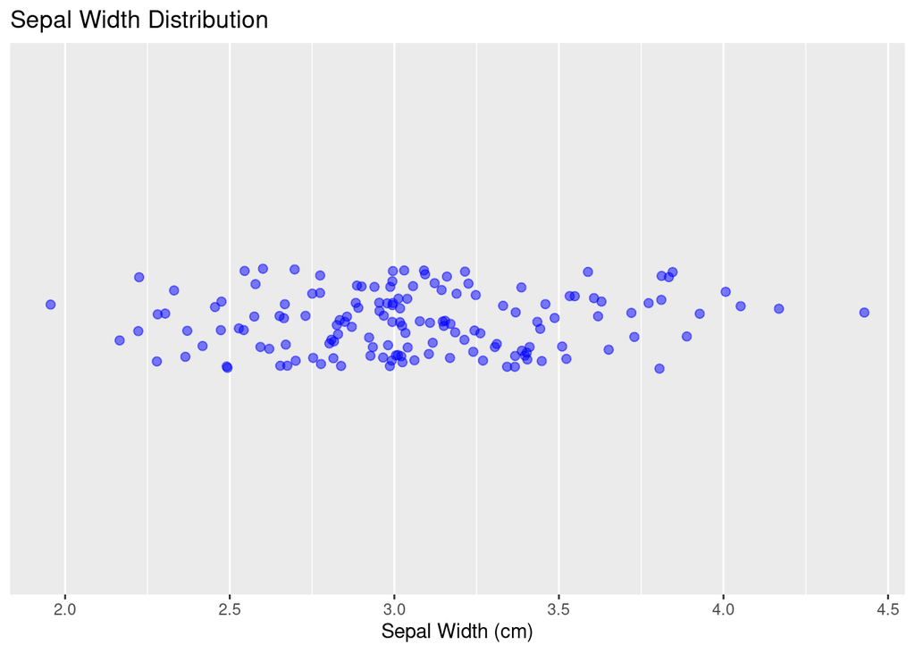

```r
ggplot(data = iris) +
  geom_jitter(aes(x=Sepal.Width, y=0),
              width = 0.05,
              height = 0.2,
              color = "blue",
              alpha = 0.5,
              pch = 19,
              cex = 2) +
  scale_y_continuous(limits = c(-1, 1),breaks = NULL, labels = NULL) +
  labs(title = "Sepal Width Distribution",
       y = NULL,
       x = "Sepal Width (cm)")
```

### Strip Chart Divided into Groups, ggplot2

This is fairly easy to do with ggplot2, as `geom_jitter()` by default takes two variables as parameters. One can be the categorical group, iris species.

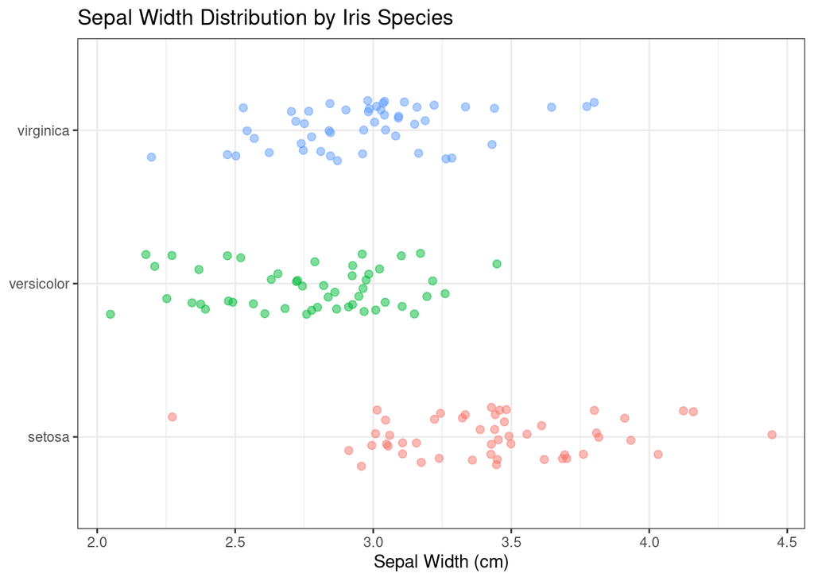

```r
ggplot(data = iris) +
  geom_jitter(aes(y=Species, x=Sepal.Width, color = Species),
              width = 0.05,
              height = 0.2,
              alpha = 0.5,
              pch = 19,
              cex = 2) +
  labs(title = "Sepal Width Distribution by Iris Species",
       x = "Sepal Width (cm)",
       y = NULL) +
  theme_bw() +
  theme(legend.position = "none")
```

### Strip Chart with NBA Data, ggplot2

Strip charts are particularly useful with small datasets. The NBA data has a small number of players per team, so let’s try to use strip charts to compare the distribution of scoring on NBA teams, similar to the comparisons in the violin plot section.

#### Basic Strip Chart of NBA Scoring with ggplot2

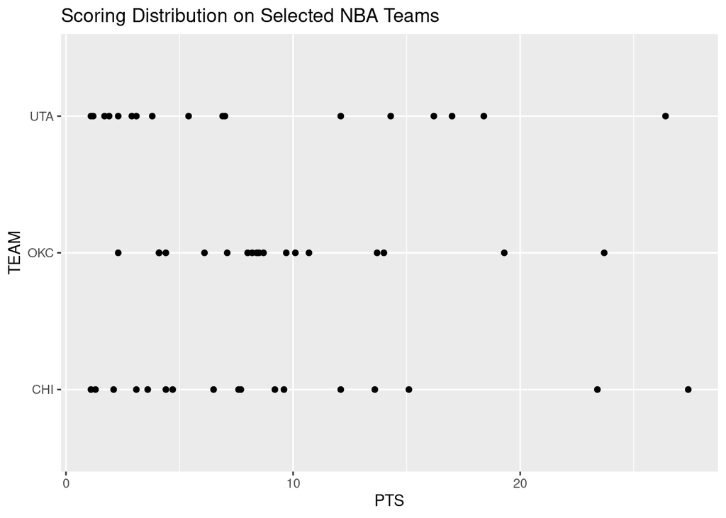

```r
nba_players %>%
  filter(TEAM %in% c("OKC", "UTA", "CHI")) %>%
  ggplot(aes(x =PTS, y = TEAM)) +
    geom_point() +
    labs(title = "Scoring Distribution on Selected NBA Teams")
```

#### More Customized Strip Chart of NBA Scoring with ggplot2

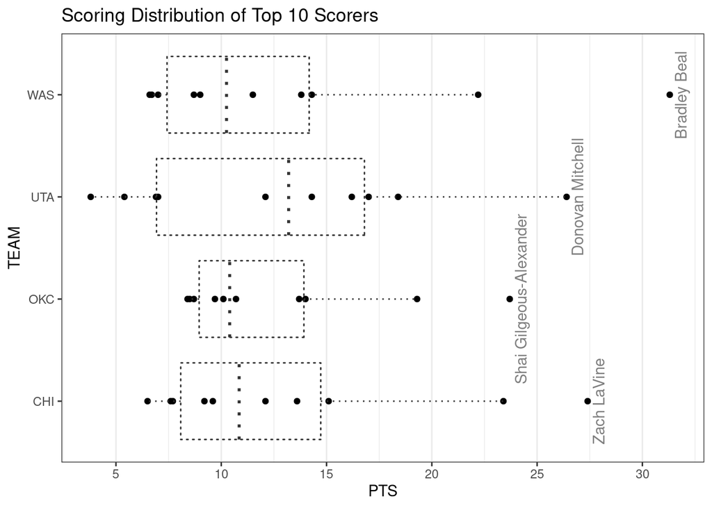

```r
top_ten <- nba_players %>%
  filter(TEAM %in% c("OKC", "UTA", "CHI", "WAS")) %>%
  group_by(TEAM) %>%
  arrange(desc(PTS), .by_group = TRUE) %>%
  mutate(rn = row_number()) %>%
  filter(rn <= 10)

top_one <- nba_players %>%
  filter(TEAM %in% c("OKC", "UTA", "CHI", "WAS")) %>%
  group_by(TEAM) %>%
  filter(row_number(desc(PTS)) == 1)

ggplot(data = top_ten, aes(x =PTS, y = TEAM)) +
  geom_point() +
  scale_x_continuous(breaks = seq(5, 30, 5)) +
  geom_text(aes(label = PLAYER),
            data = top_one,
            nudge_x = 0.25,
            angle = 90,
            alpha = 0.5,
            vjust = "top",
            hjust = "middle") +
  labs(title = "Scoring Distribution of Top 10 Scorers") +
  theme_bw() +
  theme(panel.grid.major.y = element_blank()) +
  geom_boxplot(alpha = 0,
               linetype = 3)
```

## Strip Plot showing the distribution of a numberic variable by a categorical variable

```r
#This example is similar to the one that Dr. Haney did above, this time with a different dataset with new variables.
data(chickwts)
str(chickwts)
```

```
## 'data.frame':    71 obs. of  2 variables:
##  $ weight: num  179 160 136 227 217 168 108 124 143 140 ...
##  $ feed  : Factor w/ 6 levels "casein","horsebean",..: 2 2 2 2 2 2 2 2 2 2 ...
```

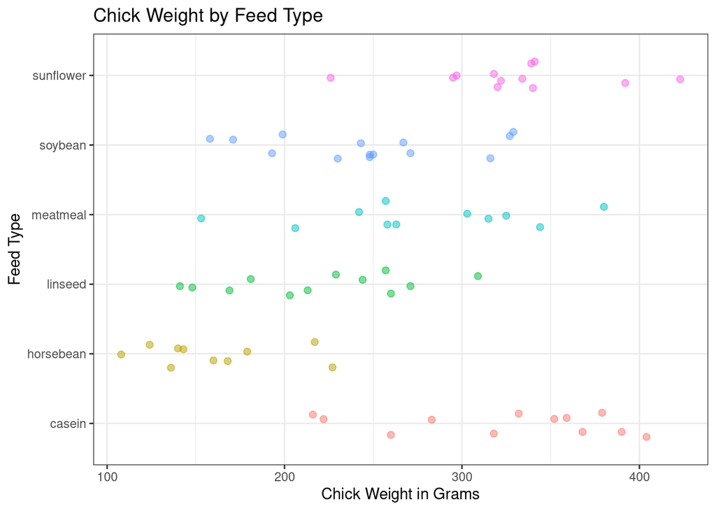

```r
#in ggplot2:
ggplot(data = chickwts) +
  geom_jitter(aes(y=feed, x=weight, color = feed),
              width = 0.05,
              height = 0.2,
              alpha = 0.5,
              pch = 19,
              cex = 2) +
  labs(title = "Chick Weight by Feed Type",
       x = "Chick Weight in Grams",
       y = "Feed Type") +
  theme_bw() +
  theme(legend.position = "none")
```

```r
# A second example, this time using the Carbon Dioxide Uptake in Grass Plants dataset
data(CO2)
str(CO2)
```

```
## Classes 'nfnGroupedData', 'nfGroupedData', 'groupedData' and 'data.frame':   84 obs. of  5 variables:
##  $ Plant    : Ord.factor w/ 12 levels "Qn1"<"Qn2"<"Qn3"<..: 1 1 1 1 1 1 1 2 2 2 ...
##  $ Type     : Factor w/ 2 levels "Quebec","Mississippi": 1 1 1 1 1 1 1 1 1 1 ...
##  $ Treatment: Factor w/ 2 levels "nonchilled","chilled": 1 1 1 1 1 1 1 1 1 1 ...
##  $ conc     : num  95 175 250 350 500 675 1000 95 175 250 ...
##  $ uptake   : num  16 30.4 34.8 37.2 35.3 39.2 39.7 13.6 27.3 37.1 ...
##  - attr(*, "formula")=Class 'formula'  language uptake ~ conc | Plant
##   .. ..- attr(*, ".Environment")=<environment: R_EmptyEnv>
##  - attr(*, "outer")=Class 'formula'  language ~Treatment * Type
##   .. ..- attr(*, ".Environment")=<environment: R_EmptyEnv>
##  - attr(*, "labels")=List of 2
##   ..$ x: chr "Ambient carbon dioxide concentration"
##   ..$ y: chr "CO2 uptake rate"
##  - attr(*, "units")=List of 2
##   ..$ x: chr "(uL/L)"
##   ..$ y: chr "(umol/m^2 s)"
```

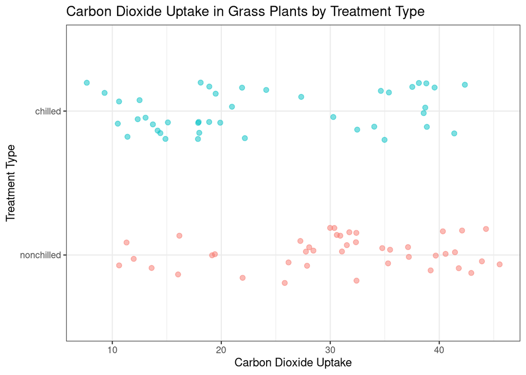

```r
ggplot(data = CO2) +
  geom_jitter(aes(y=Treatment, x=uptake, color = Treatment),
              width = 0.05,
              height = 0.2,
              alpha = 0.5,
              pch = 19,
              cex = 2) +
  labs(title = "Carbon Dioxide Uptake in Grass Plants by Treatment Type",
       x = "Carbon Dioxide Uptake",
       y = "Treatment Type") +
  theme_bw() +
  theme(legend.position = "none")
```

## Normal Probability (QQ) Plot

A quantile-quantile (“QQ”) plot is used to compare an empirical distribution to a theoretical distribution by plotting the observed quantiles vs the theoretical quantiles. They are typically used to evaluate whether or not a variable is normally distributed.

The built-in `rivers` dataset gives the lengths (in miles) of 141 rivers in North America, as compiled by the US Geological Survey. Let’s see if the river lengths are normally distributed by creating a normal probability plot of the river lengths.

### Basic QQ Plot with Normal Distribution Reference Line (Base R)

Here we create a basic QQ plot in base R and add the normal distribution QQ plot as a reference line for comparison.

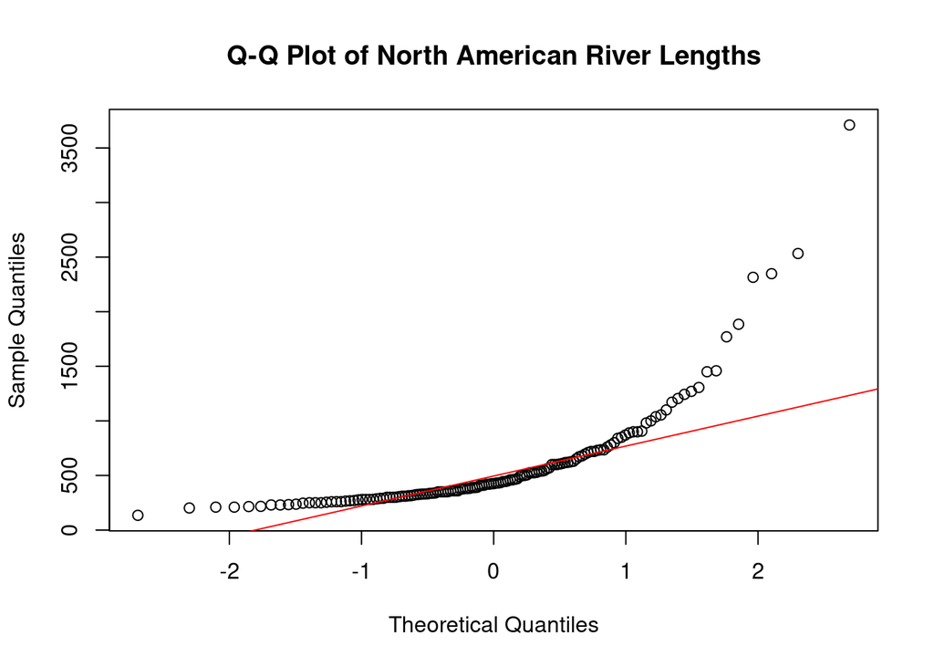

```r
qqnorm(rivers,
       main = "Q-Q Plot of North American River Lengths")
qqline(rivers, col = "red")
```

### Basic QQ Plot with Normal Distribution Reference Line (ggplot2)

Here we produce a similar plot using ggplot2. First we need to put the river lengths in a data frame.

```r
rivers_df <- data.frame(length = rivers)
```

Now we make the plot. Note that the shape and size of the geom are revised to better match the base R plot.

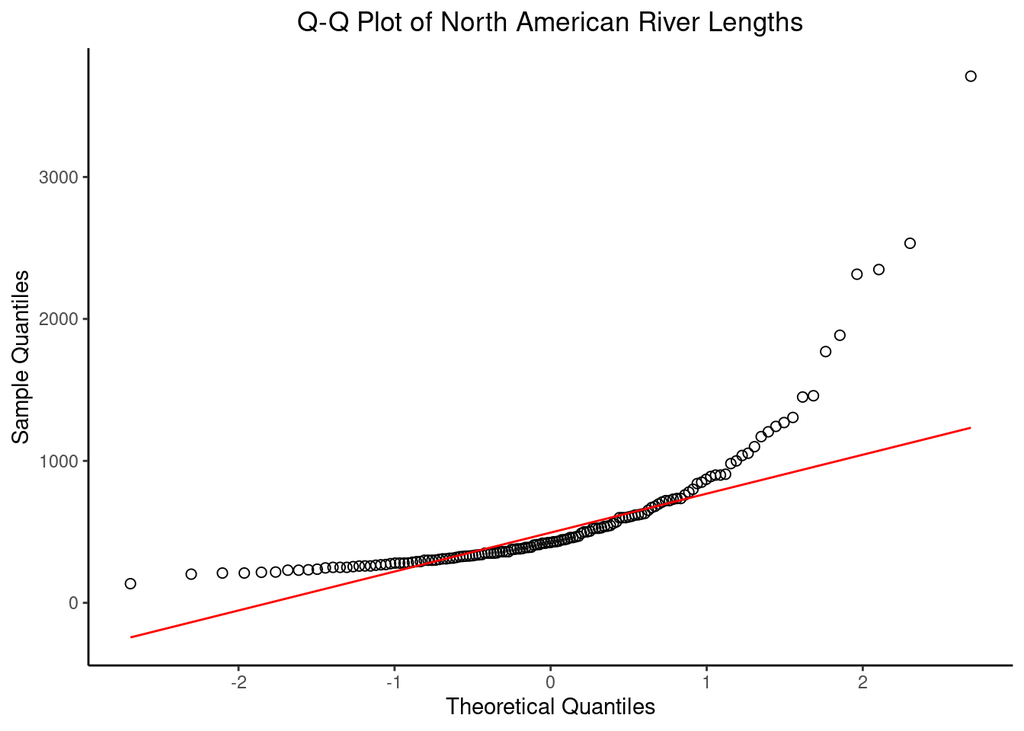

```r
ggplot(rivers_df, aes(sample = length)) +
  stat_qq(shape = 1, cex = 2) +
  stat_qq_line(color = "red") +
  labs(title = "Q-Q Plot of North American River Lengths",
       x = "Theoretical Quantiles",
       y = "Sample Quantiles") +
  theme_classic() +
  theme(plot.title = element_text(hjust = 0.5)) # Centers title
```

## Mosaic Plot

### Mosaic Plot with Base R

First, let’s read in some data on passengers who were aboard the *Titanic*.

```r
titanic <- read.csv("data/titanic.csv")
```

Next we will mosaic plot of Titanic ticket class vs embarkment location. First check to see if there is any missing data.

```r
table(titanic$Pclass)
```

```
##
##   1   2   3
## 186 173 355
```

```r
table(titanic$Embarked)
```

```
##
##       C   Q   S
##   2 130  28 554
```

Notice that there are two cases for which blank. We will remove those cases. Also, since `Pclass` is an integer vector it would be best to change it to a factor, and then specify the levels as a character vector. (See `?factor`)

```r
mask <- titanic$Embarked %in% c("C", "Q", "S")
embarked <- titanic$Embarked[mask]
class <- titanic$Pclass[mask]
class <- factor(class, levels = c(1, 2, 3),
                labels = c("First", "Second", "Third"))
```

Make the mosaic plot.

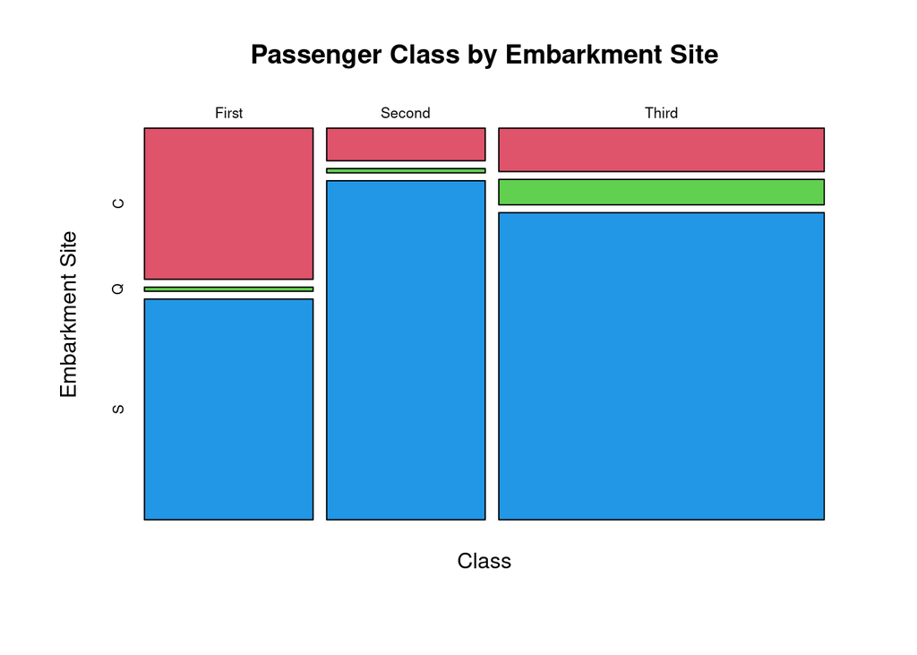

```r
mosaicplot(table(class, embarked),
           main="Passenger Class by Embarkment Site",
              xlab="Class",ylab="Embarkment Site",
              col=c(2,3,4))
```

### Mosaic Plot with ggplot2

Let’s make a similar mosaic plot using ggplot2. We need to use the ggmosaic package to do so.

```r
titanic_clean <- titanic %>%
  filter(Embarked %in% c("C", "Q", "S")) %>%  # Removes cases with missing data
  mutate(
  Embarked = factor(embarked),
  Pclass = factor(Pclass)
)

titanic_m_data <- titanic_clean %>%
  count(Embarked, Pclass)
```

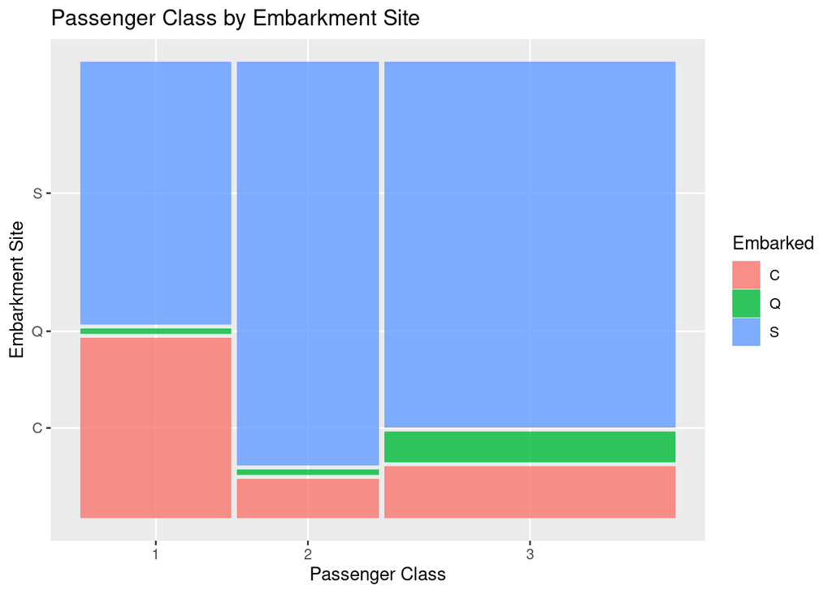

```r
  ggplot(data = titanic_m_data) +
    geom_mosaic(aes(x = product(Pclass), fill = Embarked, weight = n)) +
    xlab("Passenger Class") +
    ylab("Embarkment Site") +
  ggtitle("Passenger Class by Embarkment Site")
```

## Scatterplots

### Base R

Creating a scatterplot in base R is simple. For this example, I used the dataset pennsylvania-history, which shows the history of pennsylvania’s recorded covid cases from January to March 7. The variables of interest are positive, the number of positive cases, and deaths. Did the death count rise as cases grew?

First, we read the data file, pennsylvania-history.csv and store it as covidchart. Our x values in the plot function are covidchart$positive, and our yvalue is covidchart$death. Our title, as explaieid in main is “Covid Infection and Fatalities.” Our x-axis is labeled Infections, for covid infections, and our y axis is labeled fatalities. Note that these fatalities are not explciitly confirmed to be from Covid, but are the overall fatality count in PA over time, each point representing a different count of infection and fatality per day. We then draw a regression line based on positive cases and fatalities. The regression line is colored red and the points are colored grey after the color scheme of the virus itself.

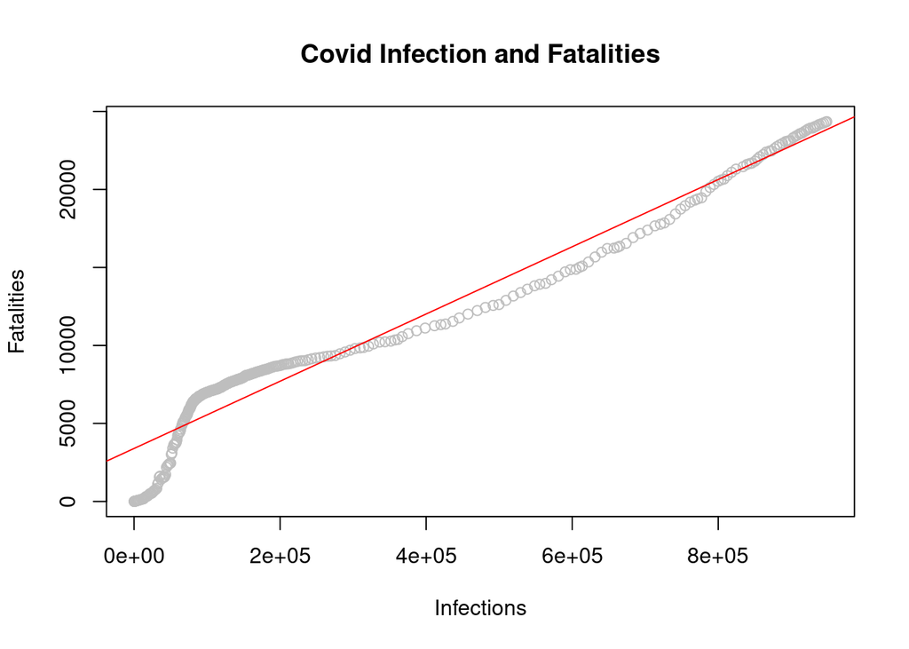

```r
covidchart <- read.csv("data/pennsylvania-history.csv")
covidchart <- subset(covidchart, !is.na(positive) & !is.na(death))
plot(covidchart$positive, covidchart$death, main = "Covid Infection and Fatalities", xlab = "Infections", ylab = "Fatalities", col = "grey")
abline(lm(covidchart$death ~ covidchart$positive), col = "red")
```

We can see that, yes, positive cases unfortunately have a positive correlation with fatalities.